# sd7answers

1. Reading in the data, setting up time series, and plots:

   ```r
   dt <- read.csv("QtrlyCommodityPriceIndex.csv")

   # log of commodity price index, 1982q3 to 2024q4
   P <- ts(dt$CommodityPriceIndex, start=c(1982,3),
           end=c(2024,4), frequency=4)
   Y <- log(P)
   DY <- diff(Y)

   # 2024 observations for forecast evaluation
   Pf <- window(P, start=c(2024,1), end=c(2024,4))
   Yf <- window(Y, start=c(2024,1), end=c(2024,4))
   DYf <- window(DY, start=c(2024,1), end=c(2024,4))

   # Estimation sample ends 2023q4
   Y <- window(Y, end=c(2023,4))
   DY <- window(DY, end=c(2023,4))
   ```

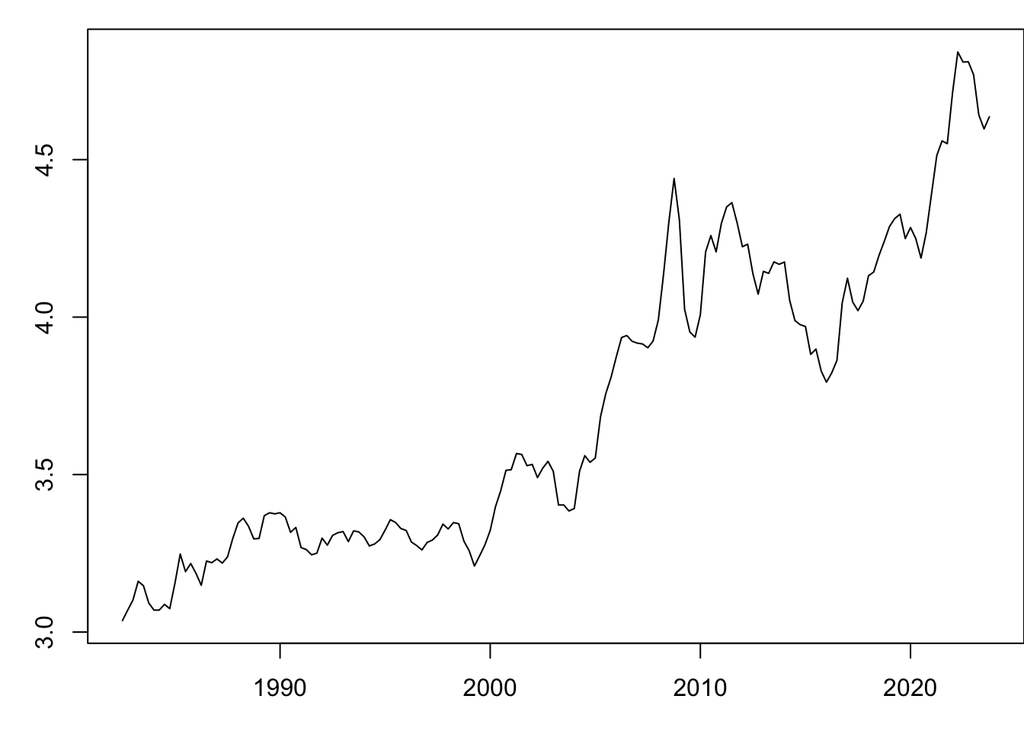

   ```r
   plot(Y)
   ```

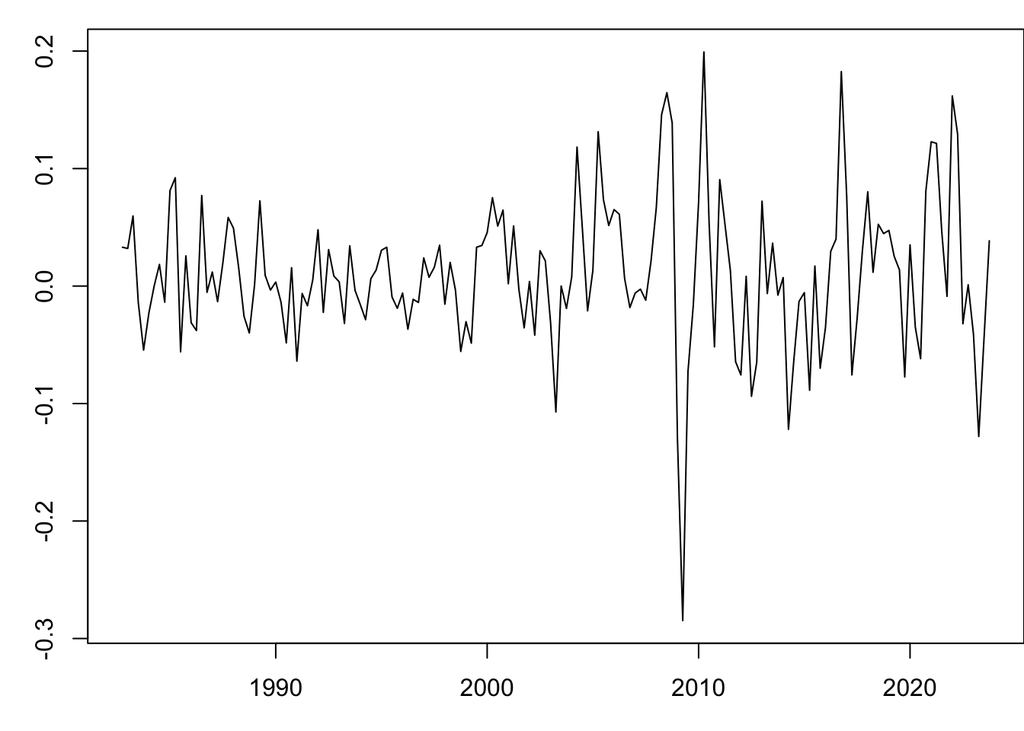

   ```r
   plot(DY)
   ```

   The plots show clear evidence of a positive trend in the log commodity price series `Y`, and a likely unit root. The difference series `DY` appears to be stationary around a constant mean.

   Here are the ADF test results to investigate more formally.

   ```r
   library(urca)
   ADF_Y <- ur.df(Y, type="trend", lags=9, selectlags="AIC")
   print(round(ADF_Y@testreg$coefficients,4))
   ```

   ```
               Estimate Std. Error t value Pr(>|t|)
   (Intercept)   0.1531     0.0781  1.9599   0.0519
   z.lag.1      -0.0513     0.0266 -1.9282   0.0557
   tt            0.0005     0.0003  2.0518   0.0419
   z.diff.lag1   0.4636     0.0793  5.8444   0.0000
   z.diff.lag2  -0.2028     0.0880 -2.3056   0.0225
   z.diff.lag3   0.0929     0.0881  1.0540   0.2936
   z.diff.lag4  -0.1953     0.0825 -2.3659   0.0193
   ```

   A lag length of $p=5$ was chosen by the AIC (i.e. $p-1=4$ lags of $\Delta Y_t$). The ADF test *p*-value is

   ```r
   cat(paste0("p = ",
     round(punitroot(ADF_Y@teststat[1], trend="ct", statistic="t"),4)))
   ```

   ```
   p = 0.6395
   ```

   The null hypothesis of a unit root is not rejected, implying we would take (at least) one difference of `Y`. To check that a second difference is not required:

   ```r
   ADF_DY <- ur.df(DY, type="drift", lags=9, selectlags="AIC")
   print(round(ADF_DY@testreg$coefficients,4))
   ```

   ```
               Estimate Std. Error t value Pr(>|t|)
   (Intercept)   0.0092     0.0047  1.9574   0.0522
   z.lag.1      -0.9378     0.1217 -7.7044   0.0000
   z.diff.lag1   0.3895     0.1074  3.6274   0.0004
   z.diff.lag2   0.1521     0.0920  1.6533   0.1004
   z.diff.lag3   0.2252     0.0803  2.8065   0.0057
   ```

   ```r
   cat(paste0("p = ",
     round(punitroot(ADF_DY@teststat[1], trend="c", statistic="t"),4)))
   ```

   ```
   p = 0
   ```

   Now $p<0.05$ so the null hypothesis of a unit root in `DY` is rejected. We would proceed using one difference of `Y`.
2. The usual approach to AR model specification for `DY`:

   ```r
   # Standard/recursive modelling approach
   library(forecast)
   pmax <- 9
   Stats <- matrix(nrow=1+pmax, ncol=3, "")
   colnames(Stats) <- c("  LBp", "  AICc", "minAICc")
   rownames(Stats) <- paste0("p=",0:pmax)

   for (p in 0:pmax){
     eq <- Arima(DY, order=c(p,0,0))
     Stats[p+1,1] <- format(round(Box.test(eq$residuals, lag=p+4,
                       type="Ljung-Box", fitdf=p)$p.value, 4), nsmall=4)
     Stats[p+1,2] <- format(round(eq$aicc,2), nsmall=2)
   }
   p <- (0:pmax)[which.min(Stats[,2])]
   Stats[p+1,"minAICc"] <- "<="
   print(Stats, quote=FALSE)
   ```

   ```
         LBp    AICc  minAICc
   p=0 0.0000 -445.79
   p=1 0.0094 -469.43
   p=2 0.0727 -474.50
   p=3 0.0716 -472.51
   p=4 0.9969 -478.64 <=
   p=5 0.8900 -476.47
   p=6 0.8155 -474.51
   p=7 0.4532 -472.36
   p=8 0.5688 -470.63
   p=9 0.5759 -468.78
   ```

   ```r
   # Maximum forecast horizon:
   hmax <- length(DYf)

   # Estimate selected model:
   eq <- Arima(DY, order=c(p,0,0))

   # Recursive forecasts out to horizon hmax:
   DYf1 <- forecast(eq, h=hmax)$mean
   print(DYf1)
   ```

   ```
               Qtr1        Qtr2        Qtr3        Qtr4
   2024 0.037143111 0.042360049 0.032187354 0.007847457
   ```

3. Now we turn to direct forecasting. We select a (potentially) different AR lag order for each forecast horizon $h=1,\ldots,4$.

   ```r
   # Direct forecasting - model selection

   # Storage for AICc and Ljung-Box p-values
   AICc <- matrix(nrow=1+pmax, ncol=hmax)
   rownames(AICc) <- paste0("p=",0:pmax)
   colnames(AICc) <- paste0("h=",1:hmax)
   LBp <- AICc

   # Loop over all forecast horizons
   for (h in 1:hmax){

     # Loop over all possible AR lag orders
     for (p in c(0,h:pmax)){

       # Estimate AR(p)
       # zeros has same length as parameters in AR(p)+intercept
       zeros <- rep(NA,p+1)
       # coefficients on first h-1 lags set to zero
       if (p>0 & h>1){
         zeros[1:(h-1)] <- 0
       }
       eq <- Arima(DY, order=c(p,0,0), fixed=zeros)
       AICc[1+p,h] <- eq$aicc

       # Ljung-Box statistic, include 4 lags beyond AR order
       LB <- Box.test(eq$residuals, lag=p+4, type="Ljung-Box")$statistic
       # Remove first h-1 lags from LB statistic
       if (h>1){
         LB <- LB-Box.test(eq$residuals, lag=h-1, type="Ljung-Box")$statistic
       }
       # p-value for LB test
       LBp[1+p,h] <- pchisq(LB, df=4, lower.tail=FALSE)

     }
   }
   print(round(LBp,4))
   ```

   ```
          h=1    h=2    h=3    h=4
   p=0 0.0000 0.0195 0.0209 0.0519
   p=1 0.0094     NA     NA     NA
   p=2 0.0727 0.0027     NA     NA
   p=3 0.0716 0.0193 0.0168     NA
   p=4 0.9969 0.6560 0.7005 0.7527
   p=5 0.8900 0.8823 0.8734 0.8601
   p=6 0.8155 0.7801 0.7640 0.7459
   p=7 0.4532 0.3484 0.3344 0.3226
   p=8 0.5688 0.4443 0.4420 0.4359
   p=9 0.5759 0.3765 0.3925 0.3949
   ```

   ```r
   print(round(AICc,2))
   ```

   ```
           h=1     h=2     h=3     h=4
   p=0 -445.79 -445.79 -445.79 -445.79
   p=1 -469.43      NA      NA      NA
   p=2 -474.50 -443.87      NA      NA
   p=3 -472.51 -443.81 -445.88      NA
   p=4 -478.64 -449.33 -451.31 -453.26
   p=5 -476.47 -448.36 -450.35 -452.14
   p=6 -474.51 -446.34 -448.28 -450.08
   p=7 -472.36 -444.38 -446.36 -448.07
   p=8 -470.63 -442.81 -444.78 -446.55
   p=9 -468.78 -441.35 -443.31 -445.06
   ```

   Notice we do not estimate any model with $p<h$, since those are not useful for *direct* forecasting (while they are used for recursive forecasting). For example an AR(1) model is useless (or at least no more useful than a simple mean) for *direct* forecasting $h=2$ two steps ahead, i.e. forecasting $Y_{n+2}$ when at time $n$, since an AR(1) model for $Y_{n+2}$ has the form
   $$\begin{align}
   \Delta Y_{n+2} &= \beta_0 + Z_{n+2} \\
   E(\, Z_{n+2} \, | \, {\mathscr{Z}}_{n+1} \, ) &= \quad
   \phi_1 Z_{n+1}
   \end{align}$$
   At time $n$ there is no point specifying a direct forecasting equation that depends on data at time $n+1$.

   ```r
   # Select lag length for each h:
   ph <- (0:pmax)[apply(AICc, 2, which.min)]
   ```

   ```
       h=1 h=2 h=3 h=4
   ph=   4   4   4   4
   ```

   The conclusions are that we will use AR models of orders $p=4$ for forecasting at every horizon $h=1,2,3,4$. Notice in this case it’s a consistent story across forecast horizons. We already found the chosen AR order for 1-step-ahead forecasting was $p=4$:
   $$\begin{align}
   \Delta Y_t &= \beta_0 + Z_t \\
   E(\, Z_t \, | \, {\mathscr{Z}}_{t-1} \, ) &= \phi_1^{(1)} Z_{t-1} +
   \phi_2^{(1)} Z_{t-2} + \phi_3^{(1)} Z_{t-3} + \phi_4^{(1)} Z_{t-4}
   \end{align}$$
   For direct 2-step-ahead forecasting, $E( \, Y_{n+2} \, | \, {\mathscr{Y}}_n \,)$, the chosen model with $p=4$ is
   $$\begin{align}
   \Delta Y_t &= \beta_0 + Z_t \\
   E(\, Z_t \, | \, {\mathscr{Z}}_{t-2} \, ) &= \quad
   \phi_2^{(2)} Z_{t-2} + \phi_3^{(2)} Z_{t-3} + \phi_4^{(2)} Z_{t-4}
   \end{align}$$
   Note this must omit the first order lag $Z_{t-1}$ and start from lag 2, so $p=4$ implies three lags $Z_{t-2},Z_{t-3},Z_{t-4}$ with non-zero coefficients.
   Similarly for direct 3-step-ahead forecasting the chosen model with $p=4$ is
   $$\begin{align}
   \Delta Y_t &= \beta_0 + Z_t \\
   E(\, Z_t \, | \, {\mathscr{Z}}_{t-3} \, ) &= \qquad \phi_3^{(3)} Z_{t-3} + \phi_4^{(3)} Z_{t-4}
   \end{align}$$
   and for 4-steps-ahead with $p=4$:
   $$\begin{align}
   \Delta Y_t &= \beta_0 + Z_t \\
   E(\, Z_t \, | \, {\mathscr{Z}}_{t-3} \, ) &= \qquad\quad \phi_4^{(4)} Z_{t-4}
   \end{align}$$
   So in this case all of the direct forecasting models are selected to imply the longest lag that appears is $Z_{t-4}$ for every $h$. This need not always be the case, and the direct forecasting approach allows for flexibility across $h$ if that pragmatically improves forecasts (regardless of theoretical inconsistencies across $h$ that may be implied).

   Next to the forecasts:

   ```r
   # Direct forecasting - forecasts
   DYf2 <- DYf1
   for (h in 1:hmax){
     zeros <- c(rep(0,h-1),rep(NA,ph[h]-h+2))
     eq <- Arima(DY, order=c(ph[h],0,0), fixed=zeros)
     DYf2[h] <- forecast(eq, h=h)$mean[h]
   }
   print(DYf2)
   ```

   ```
               Qtr1        Qtr2        Qtr3        Qtr4
   2024 0.037143111 0.042203719 0.021322659 0.002985145
   ```

4. RMSE calculations:

   ```r
   RMSE_DY_Recursive <- sqrt(mean((DYf-DYf1)^2))
   RMSE_DY_Direct <- sqrt(mean((DYf-DYf2)^2))
   ```

   ```
        Recursive Direct
   RMSE    0.0758 0.0735
   ```

   The direct forecasts are a little more accurate according to this measure.